# Data Story on Presidential Inaugural Speech by Topic Modeling

Today, I’d love to share with you a data story on Presidential Inaugural Speech. We hope to explore the key of different inaugural speeches, including not only the key-words analysis, but the topic modeling using NMF. We hope to get a comprehensive understanding and also distinguishing results of different speeches.

Specific steps are presented as below.

Step 00 Package Preparation

Firstly, we check and install required packages as follows. Besides normally used ones, nltk is a leading Natrual Language Toolkit and sklearn is loaded for Topic Modeling.

```python
# -*- coding:utf-8 -*-
import nltk
import os
import math
import pandas as pd
import string
import csv
import numpy as np
from nltk.corpus import stopwords
from collections import Counter

from sklearn.feature_extraction.text import TfidfVectorizer, CountVectorizer
from sklearn.decomposition import NMF, LatentDirichletAllocation
```

Step 01 Text Preprocessing and Data Fetching

Before analyzing, text preprocessing including standardization, punctuation delection and word segmentation is done. A relatively mild stem function is choose to get a better result. Then, data are being fetched and processing. For reproducibility, each step is writen as function for later usage.

```python
#text preprocessing
def get_tokens(text):
    lowers=text.lower()
    del_punctua_map=dict((ord(char),None) for char in string.punctuation)
    no_punctua=lowers.translate(del_punctua_map)
    tokens=nltk.word_tokenize(no_punctua)
    return tokens

def stem_tokens(tokens,stemmer):
    stemmed=[]
    for item in tokens:
        stemmed.append(stemmer.lemmatize(item))
    return stemmed

def tf(word, count):
    return count[word] / sum(count.values())

def n_containing(word, count_list):
    return sum(1 for count in count_list if word in count)

def idf(word, count_list):
    return math.log(len(count_list) / (1 + n_containing(word, count_list)))

def tfidf(word, count, count_list):
    return tf(word, count) * idf(word, count_list)
```

Step 02 Keyword Extraction

Keywords are extracted through TF-IDF then output to “key_words.csv”

[output not shown]

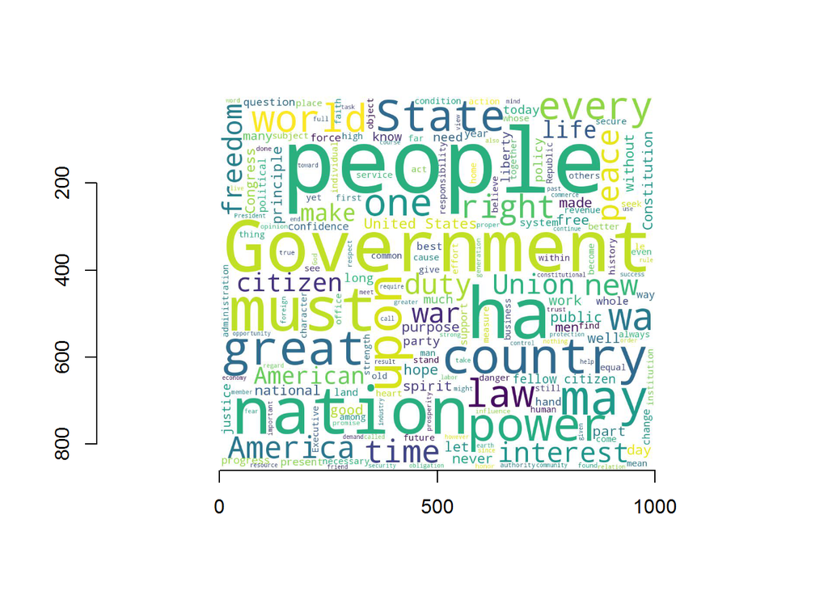

```r
options(warning = -1)
setwd("C:/Users/Jiang/Desktop/ADS/project1")
library(imager)
image <- load.image("wordCloud_allspeeches.jpg")
plot(image)
```

From the key words of each speech (show 20 of them), we can know different speeches focus on different topices, including “productivity”, “democracy”, “job” and so on, considering of different eras. What is interesting is “Obama” is the key words in DonaldTrump’s inaugural speech.

Besides, from the wordCloud of all inaugural speeches, we can find the overall characteristics–“Government”, “nation”, “people” are the most frequent words among the speeches. And “law”, “freedom”, “duty”, “power” also occurs much. These results are reasonable.

It’s not enough to use only key words to explore the topics. We need to do topic modeling using NMF, find the most common topics and their relevant speeches.

Step 03 Topic Modeling

Topic extraction results of Inaugural Speeches are written to “topic_only inaugural.csv”. Pathdir is used to deal with inaugural speech data all at the same time.

Then, Topic Modeling is done using NMF, which by compare performs better than LDA (consider the amount of data is realtively small). number of topics is set as 10 and top 4 most related inaugural speeches is given.

```python
#Topic modeling using NMF

import warnings
warnings.filterwarnings("ignore")

import nltk
import os
import pandas as pd
import numpy as np
from sklearn.feature_extraction.text import TfidfVectorizer, CountVectorizer
from sklearn.decomposition import NMF, LatentDirichletAllocation
import matplotlib.pyplot as plt

colors=['#3A8FB7','#66327C','#24936E','#F7D94C','#D7B98E','#854836','#72636E']

#output topic results to csv
def display_topics(H, W, feature_names, documents, no_top_words, no_top_documents):
    N=10
    Dic={}
    ind = np.arange(N)    # the x locations for the groups
    width = 0.35       # the width of the bars: can also be len(x) sequence

    p=[]
    p1 = plt.bar(ind, W[0], width)
    p.append(p1)
    ww=np.zeros(10)
    for i in range(56):
        for r in range(10):
            ww[r]=ww[r]+W[i][r]

        p1 = plt.bar(ind, W[i+1],width,color=colors[i%7],bottom=ww)
        p.append(p1)

    plt.ylabel('Inaugural Speech')
    plt.title('Topic Distribution')
    plt.xticks(ind, ('T1', 'T2', 'T3', 'T4', 'T5','T6','T7','T8','T9','T10'))
    plt.yticks(np.arange(0, 20, 2))
    plt.legend((p[0][0], p[1][0],p[2][0]), (pathdir[0][:-4], pathdir[1][:-4],'......\n......'))
    plt.savefig("topic_distribution.jpg")

    for topic_idx, topic in enumerate(H):
        print ("Topic %d:" % (topic_idx+1))
        print (" ".join([feature_names[i]
                        for i in topic.argsort()[:-no_top_words - 1:-1]]))

        bb=[feature_names[i] for i in topic.argsort()[:-no_top_words - 1:-1]]


        top_doc_indices = np.argsort( W[:,topic_idx] )[::-1][0:no_top_documents]
        for doc_index in top_doc_indices:
            print (pathdir[doc_index])
            bb.append(pathdir[doc_index][:-4])
        Dic.update({'Topic %d:' % (topic_idx+1):bb})
    dd=pd.DataFrame(Dic)
    dd.to_csv("topic_only inaugural.csv",index=False,sep=',')

pathdir=os.listdir('D:\\NLP\\data\\InauguralSpeeches')

txall=[]

for i in pathdir:
    f=open('D:\\NLP\\data\\InauguralSpeeches\\'+i,'r')
    tx=f.read()
    txall.append(tx)

stemmer=nltk.WordNetLemmatizer()
for i,st in enumerate(txall):
    txall[i]=nltk.word_tokenize(st)
    txall[i]=[stemmer.lemmatize(t) for t in txall[i]]
    txall[i]=' '.join(txall[i])

no_features =3000
# NMF is able to use tf-idf
tfidf_vectorizer = TfidfVectorizer(max_df=0.95, min_df=2, max_features=no_features, stop_words='english')
tfidf = tfidf_vectorizer.fit_transform(txall)
tfidf_feature_names = tfidf_vectorizer.get_feature_names()

# LDA can only use raw term counts for LDA because it is a probabilistic graphical model
'''
tf_vectorizer = CountVectorizer(max_df=0.95, min_df=2, max_features=no_features, stop_words='english')
tf = tf_vectorizer.fit_transform(txall)
tf_feature_names = tf_vectorizer.get_feature_names()
'''

no_topics =10

# Run NMF
nmf_model = NMF(n_components=no_topics, random_state=1, alpha=.1, l1_ratio=.5, init='nndsvd').fit(tfidf)
nmf_W = nmf_model.transform(tfidf)
nmf_H = nmf_model.components_

# LDA model (worse result,so give up)
'''
lda_model= LatentDirichletAllocation(n_topics=no_topics, max_iter=5, learning_method='online', learning_offset=50.,random_state=0).fit(tf)
lda_W = lda_model.transform(tf)
lda_H = lda_model.components_
'''
no_top_words =20
no_top_documents=4
display_topics(nmf_H, nmf_W, tfidf_feature_names, txall, no_top_words, no_top_documents)
#display_topics(lda_H, lda_W, tf_feature_names, txall, no_top_words, no_top_documents)
```

```
## Topic 1:
## government states public power shall country constitution union nation law duty great wa right united principle congress peace foreign citizens
## inaugJamesKPolk-1.txt
## inaugWilliamHenryHarrison-1.txt
## inaugJamesMonroe-1.txt
## inaugJamesBuchanan-1.txt
## Topic 2:
## america world nation new today let freedom americans time life know peace work god child century make american generation help
## inaugWilliamJClinton-2.txt
## inaugWilliamJClinton-1.txt
## inaugRichardNixon-2.txt
## inaugGeorgeBush-1.txt
## Topic 3:
## negro business tariff amendment south race employee proper likely canal suitable incoming philippines legislation passed trade feeling coast railroad statute
## inaugWilliamHowardTaft-1.txt
## inaugZacharyTaylor-1.txt
## inaugFranklinDRoosevelt-3.txt
## inaugJamesGarfield-1.txt
## Topic 4:
## counsel thought purpose action set thing politics shall stand current drawn industrial despite immediate principle equally life private process influence
## inaugWoodrowWilson-2.txt
## inaugWoodrowWilson-1.txt
## inaugFranklinDRoosevelt-3.txt
## inaugJamesGarfield-1.txt
## Topic 5:
## offense war god answered altogether union pray cease address wa drawn slave let shall year seeking said came conflict deprecated
## inaugAbrahamLincoln-2.txt
## inaugZacharyTaylor-1.txt
## inaugFranklinDRoosevelt-4.txt
## inaugJamesGarfield-1.txt
## Topic 6:
## previous injunction shall reposed thereof oath entertain magistrate ceremony punishment execution instance witness requires official distinguished execute function express endeavor
## inaugGeorgeWashington-2.txt
## inaugZacharyTaylor-1.txt
## inaugJamesMadison-1.txt
## inaugJamesGarfield-1.txt
## Topic 7:
## war british savage cruel prisoner captive usage wa honorable render reflect carried received battle reliance sympathy suffering issue united sense
## inaugJamesMadison-2.txt
## inaugJamesMadison-1.txt
## inaugJamesGarfield-1.txt
## inaugJamesBuchanan-1.txt
## Topic 8:
## democracy speaks know life spirit nations nation body 1789 measured peril wa later freely human sacred mind midst acted person
## inaugFranklinDRoosevelt-3.txt
## inaugJamesMadison-1.txt
## inaugJamesGarfield-1.txt
## inaugJamesBuchanan-1.txt
## Topic 9:
## dollar paying deal debt payment specie advisable desirable law question determination pay country ultimately ability best careful greatest paid requires
## inaugUlyssesSGrant-1.txt
## inaugZacharyTaylor-1.txt
## inaugFranklinDRoosevelt-3.txt
## inaugJamesGarfield-1.txt
## Topic 10:
## freedom america liberty tyranny ideal seen excuse choice defended americans came equally equality entire equal environment entitled entirely enterprise entertained
## inaugGeorgeWBush-2.txt
## inaugZacharyTaylor-1.txt
## inaugJamesMadison-1.txt
## inaugJamesGarfield-1.txt
```

From the above output, we can conclude the most likely 10 topics of the speeches, as well as the relevant speeches. And their possibility can be seen from the below bars graph.

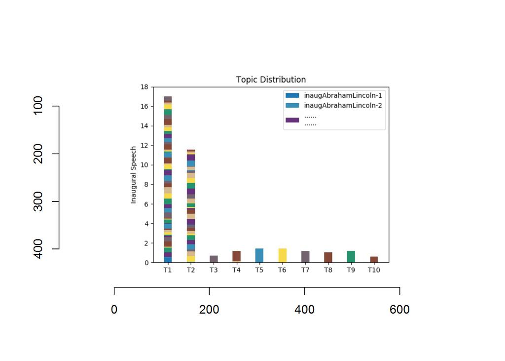

```r
options(warning = -1)
setwd("C:/Users/Jiang/Desktop/ADS/project1")
library(imager)
image2 <- load.image("topic_distribution.jpg")
plot(image2)
```

Analysis:

From the bar graphs, we know the topic1, topic2 are the most frequent topics of the speeches. And for topic3, topic5, topic7, topic8, topic 10, they mainly serve a special speech. Which speech? It can be found from the above topic-key words output.

Overall, based on the results of Topic Modeling. We’ve got some detailed and interesting results. I will explain them to you one by one on each topic.

For Topic 1, with the keywords “state”, “country”, “union”, “nation” as well as “constitution”, “law”, “duty”, “principle” and “right”, it is obviously closely related to the government and justice, like the president announces his political platform.

For Topic 2, with the keywords “American”, “nation” along with “today”, “time”, “like”, “child”, “generation”, we can easily get a feeling of sense of national pride and the hope for future generations. William J. Clinton is its typical example as someone ideologically a New Democrat and many of whose policies reflected a centrist “Third Way” political philosophy.

For Topic 3, with keywords “business”, “tariff”, “railway” and “statue”, it seems to talk about the trade development and municipal construction.

Different president from various background in different historical period focus on different topics, while some presidents, like Franklin D. Roosevelt’s speech covers a wide range of topics. This may somewhat due to the specialty of certain historical event like The New Deal. What’s more, it is at first a little bit surprising that the names of more recent presidents like Barack Obama or Donald J. Trump. After further reflection, such phenomena may be a result of social development and a stronger appeal to opening and freedom, thus the themes of presidential inaugural speeches become harder to generate or define.

Prospect:

This attempt of text mining on U.S. presidential inaugural speech mainly focus on keywords extraction and topic modeling. Based on 10 different topics, interesting stories behind presidential inaugural speech is mined and explanations are given. However, further analyzes on partisanship or relationship between presidents remain to be done. Moreover, given the limitation of time and my personal skill, more advanced methods like data visualization haven’t been included. All in all, thanks for listening to my stories and more meaningful data stories on presidential inaugural speech is there waiting for us to explore.